# 2024 09 30 Analysis_Online Retail Data_eng

### Overview of the Online Retail Dataset

##### The Online Retail dataset is a transaction dataset for a British online retailer. It contains all transactions between 01.12.2010 and 09.12.2011. The dataset includes the following information:

##### InvoiceNo

Invoice number. A unique six-digit number assigned to each transaction. If the number starts with 'C', it indicates a cancellation.

##### Description

Product description.

##### Quantity

Number of products sold per transaction.

##### InvoiceDate

Date and time of the transaction.

##### UnitPrice

Unit price of the product.

##### CustomerID

Customer number. A unique five-digit number for each customer.

##### Country

The country where the customer is located.

### Possible Analyses

##### With this dataset, we can conduct various analyses, such as:

##### Sales Analysis

Revenue over time, top products, sales trends.

##### Customer Analysis

Buying behavior, customer retention, geographic distribution of customers.

##### Product Analysis

Popular products, cancellations, stock levels.

### Steps for an Exploratory Data Analysis (EDA)

##### Data Import and Initial Inspection

Load the dataset into a pandas DataFrame. Overview of the data structure (data types, number of rows/columns). Display the first and last rows.

##### Data Cleaning

Check for missing values and decide how to handle them. Remove duplicates. Convert data types (e.g., InvoiceDate to datetime). Handle negative or unusual values (e.g., negative Quantity).

##### Descriptive Statistics

Calculate metrics such as mean, median, standard deviation. Examine the distribution of numerical variables.

##### Data Visualization

Create charts like histograms, box plots, scatter plots. Visualize trends over time.

##### Feature Engineering

Create new variables, e.g., total price (TotalPrice = Quantity * UnitPrice). Extract time information from InvoiceDate (month, weekday, hour).

##### Gaining Insights

Summarize the key findings from the analysis. Identify patterns or anomalies.

#### 1. Importing the necessary libraries

```python
import pandas as pd
import numpy as np
import matplotlib.pyplot as plt
import seaborn as sns
%matplotlib inline
```

##### Explanation:

We import the necessary libraries for data analysis and visualization. %matplotlib inline ensures that the plots are displayed directly in the notebook.

#### 2. Loading the Dataset

```python
# Assuming the file is named 'OnlineRetail.xlsx' and is located in the current directory
df = pd.read_excel('OnlineRetail.xlsx')
```

#### 3. Initial Data Inspection

```python
# Overview of the data
df.head()
```

|  | InvoiceNo | StockCode | Description | Quantity | InvoiceDate | UnitPrice | CustomerID | Country |
| --- | --- | --- | --- | --- | --- | --- | --- | --- |
| 0 | 536365 | 85123A | WHITE HANGING HEART T-LIGHT HOLDER | 6 | 2010-12-01 08:26:00 | 2.55 | 17850.0 | United Kingdom |
| 1 | 536365 | 71053 | WHITE METAL LANTERN | 6 | 2010-12-01 08:26:00 | 3.39 | 17850.0 | United Kingdom |
| 2 | 536365 | 84406B | CREAM CUPID HEARTS COAT HANGER | 8 | 2010-12-01 08:26:00 | 2.75 | 17850.0 | United Kingdom |
| 3 | 536365 | 84029G | KNITTED UNION FLAG HOT WATER BOTTLE | 6 | 2010-12-01 08:26:00 | 3.39 | 17850.0 | United Kingdom |
| 4 | 536365 | 84029E | RED WOOLLY HOTTIE WHITE HEART. | 6 | 2010-12-01 08:26:00 | 3.39 | 17850.0 | United Kingdom |

```python
# Information about the DataFrame
df.info()
```

```
<class 'pandas.core.frame.DataFrame'>
RangeIndex: 541909 entries, 0 to 541908
Data columns (total 8 columns):
 #   Column       Non-Null Count   Dtype
---  ------       --------------   -----
 0   InvoiceNo    541909 non-null  object
 1   StockCode    541909 non-null  object
 2   Description  540455 non-null  object
 3   Quantity     541909 non-null  int64
 4   InvoiceDate  541909 non-null  datetime64[ns]
 5   UnitPrice    541909 non-null  float64
 6   CustomerID   406829 non-null  float64
 7   Country      541909 non-null  object
dtypes: datetime64[ns](1), float64(2), int64(1), object(4)
memory usage: 33.1+ MB
```

```python
# Statistical metrics
df.describe()
```

|  | Quantity | InvoiceDate | UnitPrice | CustomerID |
| --- | --- | --- | --- | --- |
| count | 541909.000000 | 541909 | 541909.000000 | 406829.000000 |
| mean | 9.552250 | 2011-07-04 13:34:57.156386048 | 4.611114 | 15287.690570 |
| min | -80995.000000 | 2010-12-01 08:26:00 | -11062.060000 | 12346.000000 |
| 25% | 1.000000 | 2011-03-28 11:34:00 | 1.250000 | 13953.000000 |
| 50% | 3.000000 | 2011-07-19 17:17:00 | 2.080000 | 15152.000000 |
| 75% | 10.000000 | 2011-10-19 11:27:00 | 4.130000 | 16791.000000 |
| max | 80995.000000 | 2011-12-09 12:50:00 | 38970.000000 | 18287.000000 |
| std | 218.081158 | NaN | 96.759853 | 1713.600303 |

##### Explanation:

head() displays the first five rows. info() provides information about the columns and their data types. describe() returns statistical metrics for numerical columns.

#### 4. Checking for Missing Values

```python
# Number of missing values per column
df.isnull().sum()
```

```
InvoiceNo           0
StockCode           0
Description      1454
Quantity            0
InvoiceDate         0
UnitPrice           0
CustomerID     135080
Country             0
dtype: int64
```

##### Explanation:

Using isnull().sum(), we get the number of missing values in each column.

#### 5. Handling Missing Values

```python
# Since 'CustomerID' has missing values, we could remove those rows (not recommended though, you might end up missing a lot of important data)
df = df.dropna(subset=['CustomerID'])
```

##### Explanation:

We remove rows where 'CustomerID' is missing, as this is important for customer analyses.

#### 6. Converting Data Types

```python
# Converting 'InvoiceDate' to datetime
df.loc[:, 'InvoiceDate'] = pd.to_datetime(df['InvoiceDate'])
```

##### Explanation:

We convert the 'InvoiceDate' column to the datetime format for time series analysis.

#### 7. Handling Negative Values

```python
# Checking for negative quantities
df[df['Quantity'] < 0]
```

|  | InvoiceNo | StockCode | Description | Quantity | InvoiceDate | UnitPrice | CustomerID | Country |
| --- | --- | --- | --- | --- | --- | --- | --- | --- |
| 141 | C536379 | D | Discount | -1 | 2010-12-01 09:41:00 | 27.50 | 14527.0 | United Kingdom |
| 154 | C536383 | 35004C | SET OF 3 COLOURED FLYING DUCKS | -1 | 2010-12-01 09:49:00 | 4.65 | 15311.0 | United Kingdom |
| 235 | C536391 | 22556 | PLASTERS IN TIN CIRCUS PARADE | -12 | 2010-12-01 10:24:00 | 1.65 | 17548.0 | United Kingdom |
| 236 | C536391 | 21984 | PACK OF 12 PINK PAISLEY TISSUES | -24 | 2010-12-01 10:24:00 | 0.29 | 17548.0 | United Kingdom |
| 237 | C536391 | 21983 | PACK OF 12 BLUE PAISLEY TISSUES | -24 | 2010-12-01 10:24:00 | 0.29 | 17548.0 | United Kingdom |
| ... | ... | ... | ... | ... | ... | ... | ... | ... |
| 540449 | C581490 | 23144 | ZINC T-LIGHT HOLDER STARS SMALL | -11 | 2011-12-09 09:57:00 | 0.83 | 14397.0 | United Kingdom |
| 541541 | C581499 | M | Manual | -1 | 2011-12-09 10:28:00 | 224.69 | 15498.0 | United Kingdom |
| 541715 | C581568 | 21258 | VICTORIAN SEWING BOX LARGE | -5 | 2011-12-09 11:57:00 | 10.95 | 15311.0 | United Kingdom |
| 541716 | C581569 | 84978 | HANGING HEART JAR T-LIGHT HOLDER | -1 | 2011-12-09 11:58:00 | 1.25 | 17315.0 | United Kingdom |
| 541717 | C581569 | 20979 | 36 PENCILS TUBE RED RETROSPOT | -5 | 2011-12-09 11:58:00 | 1.25 | 17315.0 | United Kingdom |

8905 rows × 8 columns

##### Explanation:

Negative values in 'Quantity' may indicate cancellations. We can consider them separately or exclude them from specific analyses.

#### 8. Calculating Total Price

```python
# Create a new column 'TotalPrice'
df.loc[:, 'TotalPrice'] = df['Quantity'] * df['UnitPrice']
```

##### Explanation:

We create a new column that indicates the total price for each row.

#### 9. Data Visualization

##### 9.1. Revenue by Country

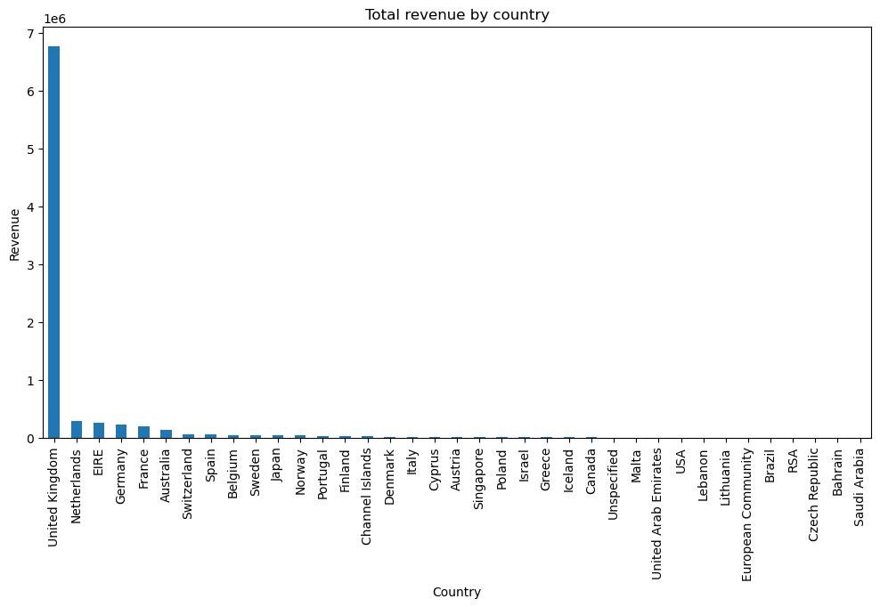

```python
# Total revenue by country
sales_country = df.groupby('Country')['TotalPrice'].sum().sort_values(ascending=False)

# Visualization
plt.figure(figsize=(12,6))
sales_country.plot(kind='bar')
plt.title('Total revenue by country')
plt.ylabel('Revenue')
plt.show()
```

##### Explanation:

We group the revenue by country and visualize it in a bar chart.

##### 9.2. Top 10 Products by Sales Quantity

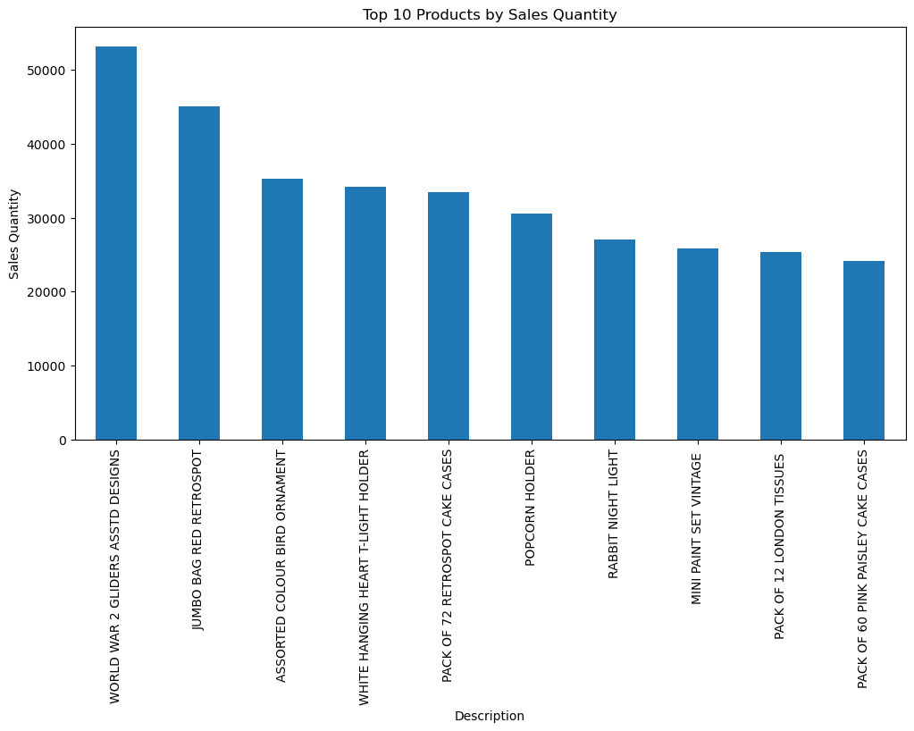

```python
# Top 10 products
top_products = df.groupby('Description')['Quantity'].sum().sort_values(ascending=False).head(10)

# Visualization
plt.figure(figsize=(12,6))
top_products.plot(kind='bar')
plt.title('Top 10 Products by Sales Quantity')
plt.ylabel('Sales Quantity')
plt.show()
```

##### Explanation:

We identify the top-selling products and visualize them.

##### 9.3. Revenue Over Time

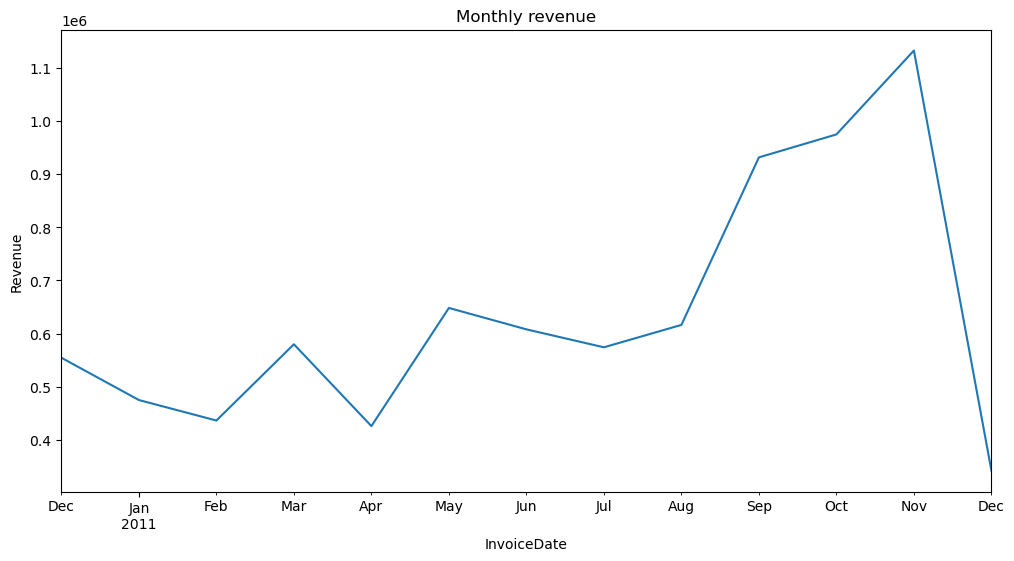

```python
# Revenue per month
df.set_index('InvoiceDate', inplace=True)
monthly_sales = df['TotalPrice'].resample('M').sum()

# Visualization
plt.figure(figsize=(12,6))
monthly_sales.plot()
plt.title('Monthly revenue')
plt.ylabel('Revenue')
plt.show()
```

##### Explanation:

We resample the data on a monthly basis to observe the revenue trend over time.

#### 10. Customer Analysis

##### 10.1. Number of Purchases per Customer

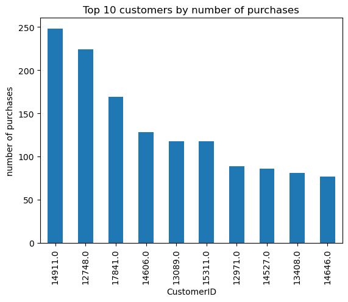

```python
# Purchases per customer
purchases_per_customer = df.groupby('CustomerID')['InvoiceNo'].nunique().sort_values(ascending=False)

# Visualization of the top 10 customers
purchases_per_customer.head(10).plot(kind='bar')
plt.title('Top 10 customers by number of purchases')
plt.ylabel('number of purchases')
plt.show()
```

##### Explanation:

We analyze which customers made the most purchases.

#### 11. Summary of Findings

After completing the EDA, you should summarize the key findings. For example, we might find:

##### Main Markets:

Most sales occur in the United Kingdom.

##### Top Products:

Certain products sell significantly better than others.

##### Customer Behavior:

Some customers make frequent purchases, indicating customer loyalty.

#### 12. Customer Lifetime Value (CLV)

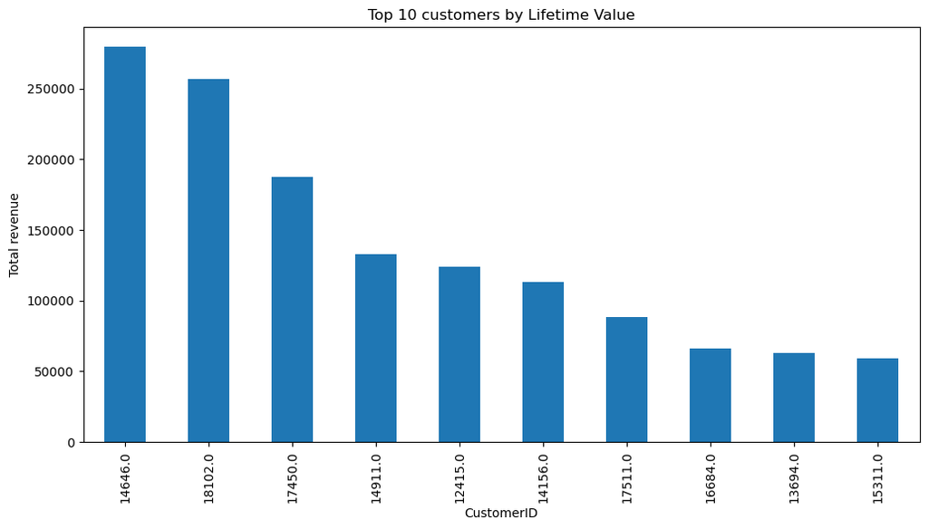

```python
# Calculating revenue per customer
clv = df.groupby('CustomerID')['TotalPrice'].sum().sort_values(ascending=False)

# Visualization of the top 10 customers with the highest customer value
clv.head(10).plot(kind='bar', figsize=(12,6))
plt.title('Top 10 customers by Lifetime Value')
plt.ylabel('Total revenue')
plt.show()
```

#### 13. Customer Retention and Repeat Purchases

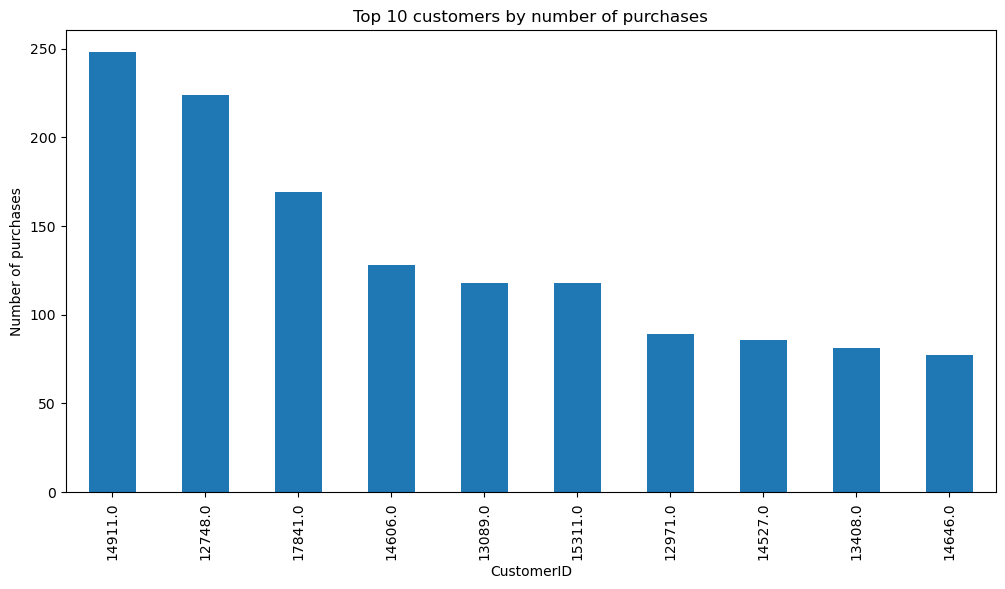

```python
# Check if 'InvoiceDate' is the index
if df.index.name == 'InvoiceDate':
    df.reset_index(inplace=True)  # Reset of the Indexes, so InvoiceDate is considered as a column again

# Number of purchases per customer
repeat_customers = df.groupby('CustomerID')['InvoiceNo'].nunique()

# Calculate average repurchase time per customer
df.loc[:, 'days_between_purchases'] = df.groupby('CustomerID')['InvoiceDate'].diff().dt.days
avg_days_between_purchases = df.groupby('CustomerID')['days_between_purchases'].mean()

# Visualization of the top 10 customers with the most purchases
repeat_customers.sort_values(ascending=False).head(10).plot(kind='bar', figsize=(12,6))
plt.title('Top 10 customers by number of purchases')
plt.ylabel('Number of purchases')
plt.show()
```

#### 14. Customer Segmentation (Clustering)

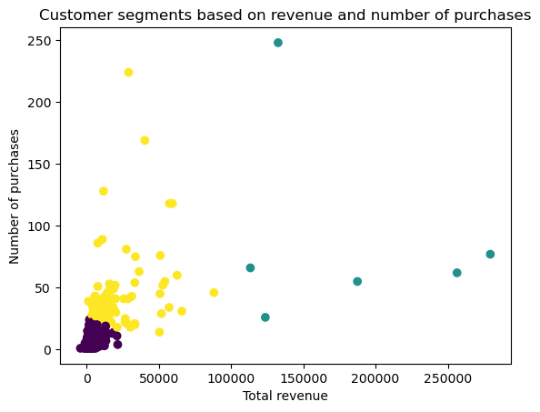

```python
from sklearn.cluster import KMeans
from sklearn.preprocessing import StandardScaler

# Data for cluster analysis (e.g., total revenue and number of purchases per customer)
customer_data = df.groupby('CustomerID').agg({
    'TotalPrice': 'sum',
    'InvoiceNo': 'nunique'
}).rename(columns={'InvoiceNo': 'NumberOfPurchases'})

# Normalize data
scaler = StandardScaler()
customer_data_scaled = scaler.fit_transform(customer_data)

# K-Means Clustering
import os
os.environ["LOKY_MAX_CPU_COUNT"] = "2"  # Example: Set the number of logical cores to 2

kmeans = KMeans(n_clusters=3, random_state=0, n_init=10)
customer_data['Cluster'] = kmeans.fit_predict(customer_data_scaled)

# Visualization of the clusters
plt.scatter(customer_data['TotalPrice'], customer_data['NumberOfPurchases'], c=customer_data['Cluster'], cmap='viridis')
plt.title('Customer segments based on revenue and number of purchases')
plt.xlabel('Total revenue')
plt.ylabel('Number of purchases')
plt.show()
```

#### 15. Product and Assortment Optimization

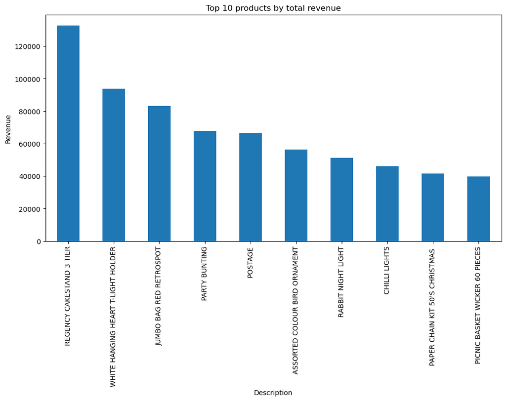

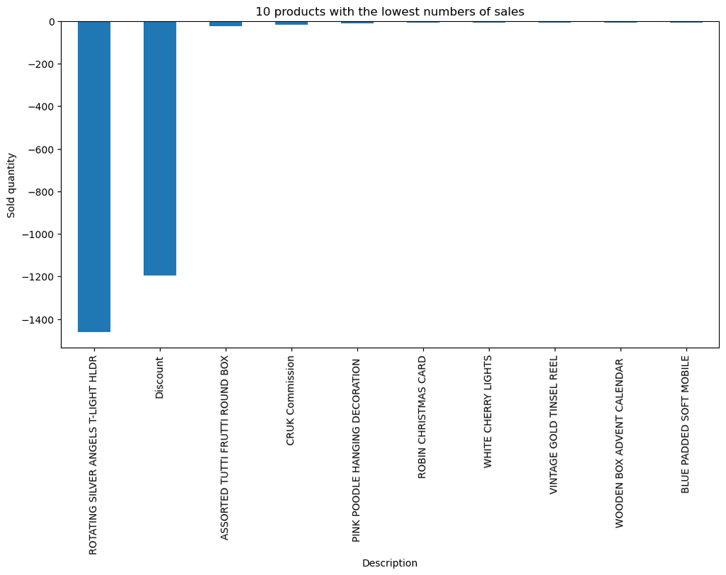

```python
# Products with the highest revenue
product_sales = df.groupby('Description')['TotalPrice'].sum().sort_values(ascending=False)

# Products with the lowest sales
low_sales_products = df.groupby('Description')['Quantity'].sum().sort_values()

# Visualization of the top 10 highest-revenue products
product_sales.head(10).plot(kind='bar', figsize=(12,6))
plt.title('Top 10 products by total revenue')
plt.ylabel('Revenue')
plt.show()

# Visualization of the 10 lowest-selling products
low_sales_products.head(10).plot(kind='bar', figsize=(12,6))
plt.title('10 products with the lowest numbers of sales')
plt.ylabel('Sold quantity')
plt.show()
```

#### 16. Cancellation Analysis

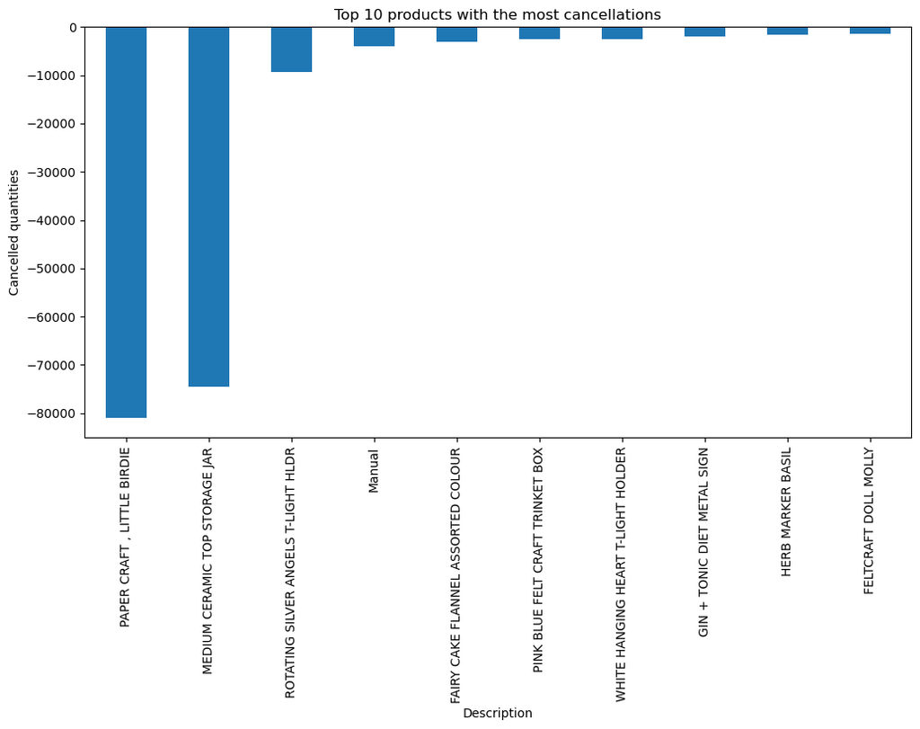

```python
# Analysis of cancellations (negative quantities)
cancellations = df[df['Quantity'] < 0]

# Top products with the most cancellations
top_cancellations = cancellations.groupby('Description')['Quantity'].sum().sort_values()

# Visualization of the top 10 products with the most cancellations
top_cancellations.head(10).plot(kind='bar', figsize=(12,6))
plt.title('Top 10 products with the most cancellations')
plt.ylabel('Cancelled quantities')
plt.show()
```

#### 17. International Expansion

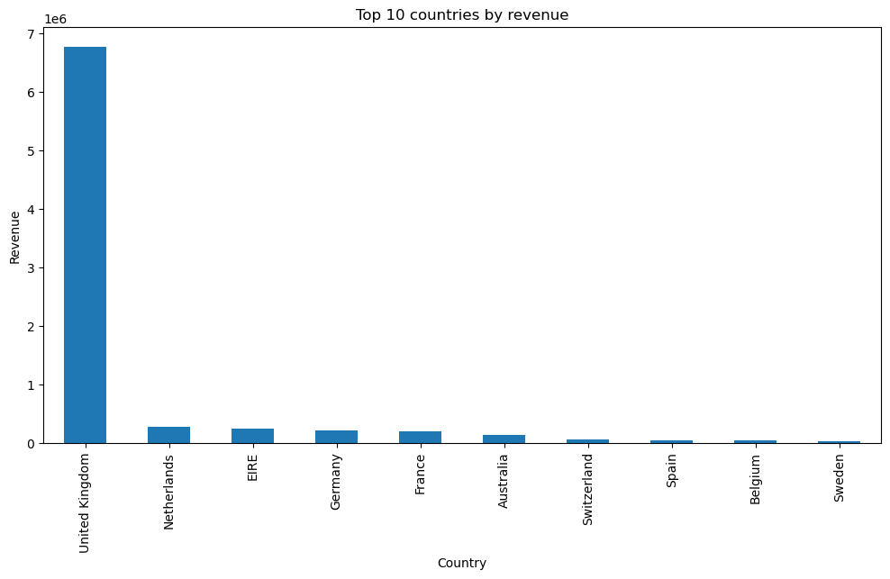

```python
# Revenue by country
sales_country = df.groupby('Country')['TotalPrice'].sum().sort_values(ascending=False)

# Visualization of the top 10 countries by revenue
sales_country.head(10).plot(kind='bar', figsize=(12,6))
plt.title('Top 10 countries by revenue')
plt.ylabel('Revenue')
plt.show()
```